# Schéma : nycflights

nycflights, R-project, relationnel, pattes de corbeau, crowfoot

nycflights

R-project

crowfoot

DDL

Published

September 20, 2024

Présentation du schéma `nycflights`, pour l’entrainement à PostGres.

- **L3 MIASHS/Ingémath**
- **[Université Paris Cité](https://www.u-paris.fr)**
- Année 2025-2026
- [Course Homepage](https://bgentou.github.io/MA15E045/)
- [Moodle](https://moodle.u-paris.fr/course/view.php?id=2313)

Ce jeu de données est construit à partir du package [`nycflights13`](https://github.com/tidyverse/nycflights13).

> The `nycflights13` package contains information about all flights that departed from NYC (e.g. EWR, JFK and LGA) to destinations in the United States, Puerto Rico, and the American Virgin Islands) in 2013: 336,776 flights in total. To help understand what causes delays, it also includes a number of other useful datasets.

> This package provides the following data tables.
> - `flights`: all flights that departed from NYC in 2013
> - `weather`: hourly meterological data for each airport
> - `planes`: construction information about each plane
> - `airports`: airport names and locations
> - `airlines`: translation between two letter carrier codes and names

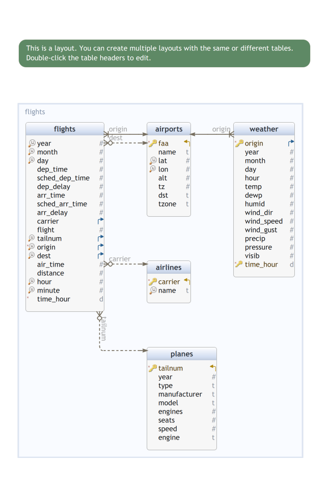

Schema `nycflights` Generated using [DbSchema](https://dbschema.com)

## Table nycflights.airlines

| Idx | Name | Data Type |
| --- | --- | --- |
| * 🔑 ⬋ | carrier | text |
| 🔍 | name | text |

## Table nycflights.airports

| Idx | Name | Data Type |
| --- | --- | --- |
| * 🔑 ⬋ | faa | text |
|  | name | text |
| 🔍 | lat | double precision |
| 🔍 | lon | double precision |
|  | alt | double precision |
|  | tz | double precision |
|  | dst | text |
|  | tzone | text |

## Table nycflights.flights

| Idx | Name | Data Type |
| --- | --- | --- |
| 🔍 | year | integer |
| 🔍 | month | integer |
| 🔍 | day | integer |
|  | dep_time | integer |
|  | sched_dep_time | integer |
|  | dep_delay | double precision |
|  | arr_time | integer |
|  | sched_arr_time | integer |
|  | arr_delay | double precision |
| ⬈ | carrier | text |
|  | flight | integer |
| 🔍 ⬈ | tailnum | text |
| * 🔍 ⬈ | origin | text |
| 🔍 ⬈ | dest | text |
|  | air_time | double precision |
|  | distance | double precision |
| 🔍 | hour | double precision |
| 🔍 | minute | double precision |
| * | time_hour | timestamptz |

`distance` est la distance orthodromique (*earth distance*) entre `origin` et `dest` en miles (pas en miles nautiques). On peut le vérifier avec les fonctions de l’extension `earthdistance`.

le vol est effectué si `dep_time` n’est pas `NULL`

##### Foreign Keys

| Type | Name | On |
| --- | --- | --- |
|  | flights_fk | ( carrier ) ref nycflights.airlines (carrier) |
|  | flights_fk_planes | ( tailnum ) ref nycflights.planes (tailnum) |
|  | flights_fk_origin | ( origin ) ref nycflights.airports (faa) |
|  | flights_fk_dest | ( dest ) ref nycflights.airports (faa) |

## Table nycflights.planes

| Idx | Name | Data Type |
| --- | --- | --- |
| * 🔑 ⬋ | tailnum | text |
|  | year | integer |
|  | type | text |
|  | manufacturer | text |
|  | model | text |
|  | engines | integer |
|  | seats | integer |
|  | speed | integer |
|  | engine | text |

## Table nycflights.weather

| Idx | Name | Data Type |
| --- | --- | --- |
| * 🔑 ⬈ | origin | text |
|  | year | integer |
|  | month | integer |
|  | day | integer |
|  | hour | integer |
|  | temp | double precision |
|  | dewp | double precision |
|  | humid | double precision |
|  | wind_dir | double precision |
|  | wind_speed | double precision |
|  | wind_gust | double precision |
|  | precip | double precision |
|  | pressure | double precision |
|  | visib | double precision |
| * 🔑 | time_hour | timestamptz |

##### Foreign Keys

| Type | Name | On |
| --- | --- | --- |
|  | weather_fk | ( origin ) ref nycflights.airports (faa) |